# Zeta_Disease_Prediction

## **Problem**

Mars Mission Control needs a good data-driven system for predicting Zeta Disease infection on the International Mars Colony. Use the `_zeta-disease_training-data_` dataset to build a model that can predict who will be infected by Zeta Disease. Apply your model to the `_zeta-disease_prediction-data_` dataset to predict who will be infected by Zeta Disease.

```python
## Import required packages

from platform import python_version
import pandas as pd
import warnings
warnings.filterwarnings('ignore')

import seaborn as sns
from sklearn.model_selection import train_test_split
from sklearn.metrics import confusion_matrix,  precision_recall_curve, average_precision_score, classification_report
from sklearn.pipeline import Pipeline
from sklearn.preprocessing import StandardScaler
from sklearn.model_selection import cross_validate
from sklearn.svm import LinearSVC
from sklearn.linear_model import LogisticRegression
from sklearn.neighbors import KNeighborsClassifier
from sklearn.tree import DecisionTreeClassifier
from sklearn.ensemble import RandomForestClassifier, GradientBoostingClassifier
```

### Platform Details

```python
print("Python Version:\n", python_version())
print("Jupyter Version: ")
!jupyter --version
```

```
Python Version:
 3.7.1
Jupyter Version:
4.4.0
```

### Load Data

```python
## Load the input training dataset

df = pd.read_csv('../Input/recruiting_zeta-disease_training-data_take-home-challenge - 2021_zeta-disease_training-data_take-home-challenge.csv')
```

### Preview Data for data types and missing values

```python
## preview data

df.head()
```

|  | age | weight | bmi | blood_pressure | insulin_test | liver_stress_test | cardio_stress_test | years_smoking | zeta_disease |
| --- | --- | --- | --- | --- | --- | --- | --- | --- | --- |
| 0 | 54 | 189 | 27.1 | 80 | 0 | 1.5038 | 0 | 10 | 0 |
| 1 | 23 | 150 | 38.5 | 68 | 71 | 0.3868 | 55 | 2 | 0 |
| 2 | 47 | 186 | 29.9 | 90 | 0 | 0.2728 | 0 | 7 | 0 |
| 3 | 18 | 150 | 30.8 | 70 | 1033 | 0.6598 | 56 | 0 | 0 |
| 4 | 24 | 160 | 32.4 | 74 | 125 | 0.7608 | 59 | 2 | 0 |

```python
## check the data for missing values in any columns

df.isnull().sum()
```

```
age                   0
weight                0
bmi                   0
blood_pressure        0
insulin_test          0
liver_stress_test     0
cardio_stress_test    0
years_smoking         0
zeta_disease          0
dtype: int64
```

```python
## check training data is balenced

df['zeta_disease'].value_counts()
```

```
0    521
1    279
Name: zeta_disease, dtype: int64
```

```python
(279/800)*100, 100 - (279/800)*100
```

```
(34.875, 65.125)
```

### Data Visualization

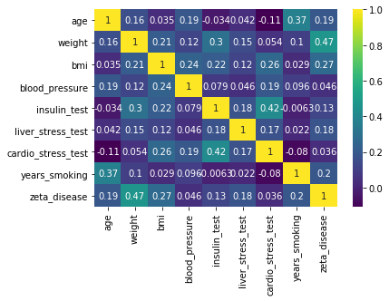

```python
## Visualizing correlation between data points
## to check if any features have high correlation with one another, so they can be remove - none found

sns.heatmap(df.corr(), annot=True,  cmap='viridis')
```

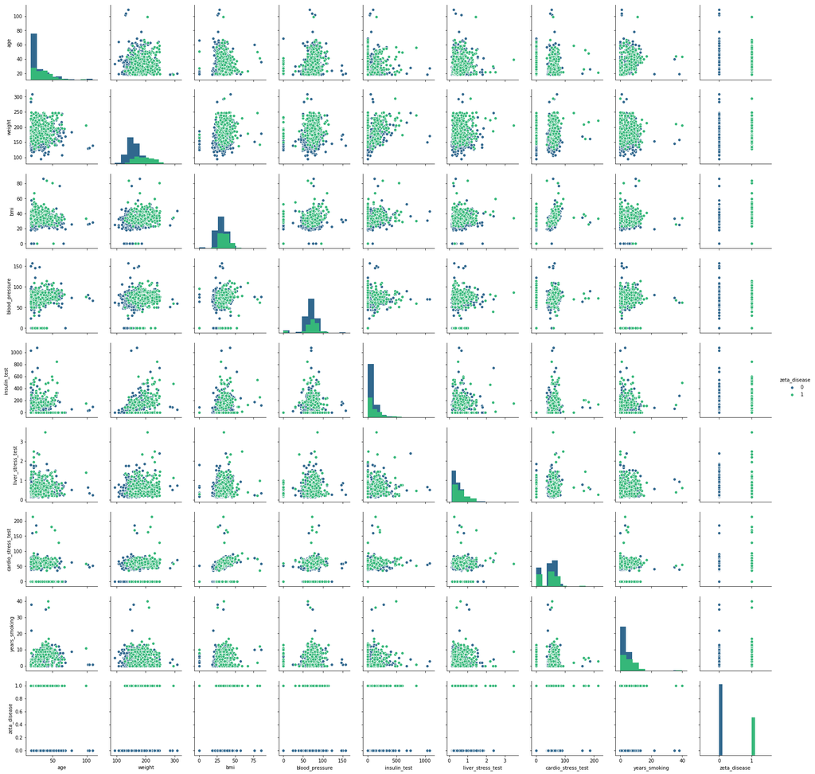

```python
## Visualing each feature and its relationship with zeta_disease feature

sns.pairplot(df, hue='zeta_disease', palette='viridis', diag_kind='hist')
```

### Feature Engineering

```python
## bmi is usually interpreted in category as below
# Below 18.5	Underweight
# 18.5–24.9	Healthy
# 25–29.9	Overweight
# 30 and above	Obese

def bmi_category(x):
    if x < 18.5:
        return 1
    elif x >= 18.5 and x <= 24.9:
        return 2
    elif x >= 25 and x <= 29.9:
        return 3
    else:
        return 4
```

```python
df['bmi_category'] = df['bmi'].apply(lambda x: bmi_category(x))
```

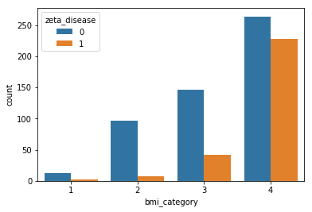

```python
sns.countplot(data= df, x= 'bmi_category', hue='zeta_disease')
```

```python
df.drop('bmi', axis = 1, inplace = True)
```

### Split Dataset into Train and Test sets

```python
#Seperate train and test data
X_train, X_test, y_train, y_test = train_test_split(df.drop('zeta_disease', axis=1),
                                                   df['zeta_disease'],
                                                   test_size = 0.3,
                                                   random_state = 101)
print(X_train.shape)
print(X_test.shape)
print(y_train.shape)
print(y_test.shape)
```

```
(560, 8)
(240, 8)
(560,)
(240,)
```

```python
pipeline = Pipeline([
    ('normalizer', StandardScaler()),
    ('clf', LogisticRegression())
])
pipeline.steps
```

```
[('normalizer', StandardScaler()), ('clf', LogisticRegression())]
```

```python
scores = cross_validate(pipeline, X_train, y_train)
scores
```

```
{'fit_time': array([0.01200485, 0.01499891, 0.01300216, 0.01199245, 0.01199961]),
 'score_time': array([0.00499558, 0.00600219, 0.00700426, 0.00300169, 0.00299954]),
 'test_score': array([0.73214286, 0.83035714, 0.75      , 0.75892857, 0.80357143])}
```

```python
clfs = []
clfs.append(LogisticRegression())
clfs.append(KNeighborsClassifier(n_neighbors=5))
clfs.append(LinearSVC())
clfs.append(DecisionTreeClassifier())
clfs.append(RandomForestClassifier())
clfs.append(GradientBoostingClassifier())
```

```python
### using sklearn library to measure Classification Metrics

def Metrics(Y, T):
    confusion = confusion_matrix(Y,T)
    print("Confussion Matrix is" )
    print(confusion)
    TP = confusion[1, 1]
    TN = confusion[0, 0]
    FP = confusion[0, 1]
    FN = confusion[1, 0]
    print("Classification Report")
    print(classification_report(T, Y))
    accuracy_score = ((TP + TN) / float(TP + TN + FP + FN))
    print("accuracy score: {:.2f}%".format(100 * accuracy_score))
    recall = (TP / float(FN + TP))
    print("sensitivity (or recall): {:.2f}%".format(100 * recall))
    precision = (TP / float(TP + FP))
    print("precision: {:.2f}%".format(100 * precision))
    f1 = (2*recall*precision)/(precision+recall)
    print("f1 score: {:.2f}%".format(100 * f1))
    fpr, tpr, thresholds = precision_recall_curve(T, Y)
    auc_score = average_precision_score(T,Y)
    print("auc score: {:.2f}%".format(100 * auc_score))
    return {"accuray":accuracy_score, "precision":precision, "recall":recall, "f1":f1, "auc":auc_score, "fpr":fpr,"tpr":tpr}
```

```python
## Train the model for various algorithms and check the metrics to find how its predictions are overall and class wise

for classifier in clfs:
    pipeline.set_params(clf = classifier)
    scores = cross_validate(pipeline, X_train, y_train)
    print('---------------------------------')
    print(str(classifier))
    print(pipeline.steps)
    print('-----------------------------------')
    for key, values in scores.items():
            print(key,' mean ', values.mean())
            print(key,' std ', values.std())
    pipeline.fit(X_train, y_train)
    print(Metrics(y_test, pipeline.predict(X_test)))
    print('-----------------------------------')
```

```
---------------------------------
LogisticRegression()
[('normalizer', StandardScaler()), ('clf', LogisticRegression())]
-----------------------------------
fit_time  mean  0.012595367431640626
fit_time  std  0.002153108644491007
score_time  mean  0.0033926963806152344
score_time  std  0.0013568350016460514
test_score  mean  0.775
test_score  std  0.0363339106238854
Confussion Matrix is
[[132  13]
 [ 47  48]]
Classification Report
              precision    recall  f1-score   support

           0       0.91      0.74      0.81       179
           1       0.51      0.79      0.62        61

    accuracy                           0.75       240
   macro avg       0.71      0.76      0.72       240
weighted avg       0.81      0.75      0.76       240

accuracy score: 75.00%
sensitivity (or recall): 50.53%
precision: 78.69%
f1 score: 61.54%
auc score: 45.18%
{'accuray': 0.75, 'precision': 0.7868852459016393, 'recall': 0.5052631578947369, 'f1': 0.6153846153846153, 'auc': 0.45175079091170545, 'fpr': array([0.25416667, 0.50526316, 1.        ]), 'tpr': array([1.        , 0.78688525, 0.        ])}
-----------------------------------
---------------------------------
KNeighborsClassifier()
[('normalizer', StandardScaler()), ('clf', KNeighborsClassifier())]
-----------------------------------
fit_time  mean  0.006904315948486328
fit_time  std  0.0009223906164571925
score_time  mean  0.00939173698425293
score_time  std  0.00048510452189188234
test_score  mean  0.7589285714285715
test_score  std  0.031943828249996996
```

[output cut: 125 more lines]

```

           0       0.86      0.78      0.81       160
           1       0.62      0.74      0.67        80

    accuracy                           0.76       240
   macro avg       0.74      0.76      0.74       240
weighted avg       0.78      0.76      0.77       240

accuracy score: 76.25%
sensitivity (or recall): 62.11%
precision: 73.75%
f1 score: 67.43%
auc score: 54.55%
{'accuray': 0.7625, 'precision': 0.7375, 'recall': 0.6210526315789474, 'f1': 0.6742857142857144, 'auc': 0.5455263157894737, 'fpr': array([0.33333333, 0.62105263, 1.        ]), 'tpr': array([1.    , 0.7375, 0.    ])}
-----------------------------------
```

## Review the test scores for both classes

LinearSVC LogisticRegression, RandomForestClassifier, GradientBoostingClassifier have test scores > 76%

But on looking at the prediction for each class (0 or 1), the scores are low for class `zeta_disease = 1`. The best is RandomForestClassifier with 63% precision.

Given the problem is about a disease prediction, If disease is predicted false given a patient has a disease, it could lead to life threating conditions. So improving precision of class `zeta_disease = 1` is important here.

I feel the poorer predictions for class `zeta_disease = 1` is due lower number of samples for class 1, sample ratio for classess 1:0 is 34.875:65.125

## Solution

Using SMOTE technique to balance the dataset by re-sampling the minority class to create equal number data points and re-train the models

```python
### Adding more imports for libraries required

from imblearn.over_sampling import SMOTE
from collections import Counter
from sklearn.model_selection import RandomizedSearchCV
import numpy as np
import joblib
import shap
```

```python
smote = SMOTE(sampling_strategy='minority')
```

```python
X_smote, Y_smote = smote.fit_resample(df.drop('zeta_disease', axis = 1), df['zeta_disease'])
```

```python
print('Resampled dataset shape %s' % Counter(Y_smote))
```

```
Resampled dataset shape Counter({0: 521, 1: 521})
```

```python
X_train_sm, X_test_sm, y_train_sm, y_test_sm = train_test_split(X_smote,
                                                  Y_smote,
                                                  test_size = 0.3,
                                                  random_state = 101)
print(X_train.shape)
print(X_test.shape)
print(y_train.shape)
print(y_test.shape)
```

```
(560, 8)
(240, 8)
(560,)
(240,)
```

```python
pipeline_sm = Pipeline([
    ('normalizer', StandardScaler()),
    ('clf', LogisticRegression())
])
pipeline_sm.steps
```

```
[('normalizer', StandardScaler()), ('clf', LogisticRegression())]
```

```python
for classifier in clfs:
    pipeline_sm.set_params(clf = classifier)
    scores = cross_validate(pipeline_sm, X_train_sm, y_train_sm)
    print('---------------------------------')
    print(str(classifier))
    print(pipeline_sm.steps)
    print('-----------------------------------')
    for key, values in scores.items():
            print(key,' mean ', values.mean())
            print(key,' std ', values.std())
    pipeline_sm.fit(X_train_sm, y_train_sm)
    print(Metrics(y_test_sm, pipeline_sm.predict(X_test_sm)))
    print('-----------------------------------')
```

```
---------------------------------
LogisticRegression()
[('normalizer', StandardScaler()), ('clf', LogisticRegression())]
-----------------------------------
fit_time  mean  0.020597171783447266
fit_time  std  0.006408564119621816
score_time  mean  0.005200481414794922
score_time  std  0.0013250966992629073
test_score  mean  0.7681719414265469
test_score  std  0.01703753289259473
Confussion Matrix is
[[102  35]
 [ 55 121]]
Classification Report
              precision    recall  f1-score   support

           0       0.74      0.65      0.69       157
           1       0.69      0.78      0.73       156

    accuracy                           0.71       313
   macro avg       0.72      0.71      0.71       313
weighted avg       0.72      0.71      0.71       313

accuracy score: 71.25%
sensitivity (or recall): 68.75%
precision: 77.56%
f1 score: 72.89%
auc score: 64.51%
{'accuray': 0.7124600638977636, 'precision': 0.7756410256410257, 'recall': 0.6875, 'f1': 0.7289156626506025, 'auc': 0.645074291390186, 'fpr': array([0.49840256, 0.6875    , 1.        ]), 'tpr': array([1.        , 0.77564103, 0.        ])}
-----------------------------------
---------------------------------
KNeighborsClassifier()
[('normalizer', StandardScaler()), ('clf', KNeighborsClassifier())]
-----------------------------------
fit_time  mean  0.009197139739990234
fit_time  std  0.0029919982414107825
score_time  mean  0.01520090103149414
score_time  std  0.0047075113805172
test_score  mean  0.7764005668398678
test_score  std  0.009403042148146955
```

[output cut: 125 more lines]

```

           0       0.74      0.71      0.73       143
           1       0.77      0.79      0.78       170

    accuracy                           0.76       313
   macro avg       0.76      0.75      0.75       313
weighted avg       0.76      0.76      0.76       313

accuracy score: 75.72%
sensitivity (or recall): 76.70%
precision: 79.41%
f1 score: 78.03%
auc score: 72.09%
{'accuray': 0.7571884984025559, 'precision': 0.7941176470588235, 'recall': 0.7670454545454546, 'f1': 0.7803468208092487, 'auc': 0.720945417812783, 'fpr': array([0.54313099, 0.76704545, 1.        ]), 'tpr': array([1.        , 0.79411765, 0.        ])}
-----------------------------------
```

### Of all the algorithms, the Random forest has the best metrics - mean test score on cv, F1 score, auc score

### optimizing Random forest alogithm using randomsearch and saving it for predictions

```python
# Number of trees in random forest
n_estimators = [int(x) for x in np.linspace(start = 200, stop = 2000, num = 10)]

# Number of features to consider at every split
max_features = ['auto', 'sqrt']

# Maximum number of levels in tree
max_depth = [int(x) for x in np.linspace(10, 110, num = 11)]
max_depth.append(None)

# Minimum number of samples required to split a node
min_samples_split = [2, 5, 10]

# Minimum number of samples required at each leaf node
min_samples_leaf = [1, 2, 4]

# Method of selecting samples for training each tree
bootstrap = [True, False]

# loss funcion for spliting
criterion = ['entropy', 'gini']

# Create the random grid
random_grid = {'n_estimators': n_estimators,
               'max_features': max_features,
               'max_depth': max_depth,
               'min_samples_split': min_samples_split,
               'min_samples_leaf': min_samples_leaf,
               'bootstrap': bootstrap,
               'criterion': criterion}
print(random_grid)
```

```
{'n_estimators': [200, 400, 600, 800, 1000, 1200, 1400, 1600, 1800, 2000], 'max_features': ['auto', 'sqrt'], 'max_depth': [10, 20, 30, 40, 50, 60, 70, 80, 90, 100, 110, None], 'min_samples_split': [2, 5, 10], 'min_samples_leaf': [1, 2, 4], 'bootstrap': [True, False], 'criterion': ['entropy', 'gini']…
```

```python
# Use the random grid to search for best hyperparameters
# First create the base model to tune
rf = RandomForestClassifier()

# Random search of parameters, using 3 fold cross validation,
# search across 100 different combinations, and use all available cores
rf_random = RandomizedSearchCV(estimator = rf, param_distributions = random_grid, n_iter = 100, cv = 3, verbose=2, random_state=101, n_jobs = -1)

# Fit the random search model
rf_random.fit(X_train_sm, y_train_sm)
```

```
Fitting 3 folds for each of 100 candidates, totalling 300 fits
```

```
RandomizedSearchCV(cv=3, estimator=RandomForestClassifier(), n_iter=100,
                   n_jobs=-1,
                   param_distributions={'bootstrap': [True, False],
                                        'criterion': ['entropy', 'gini'],
                                        'max_depth': [10, 20, 30, 40, 50, 60,
                                                      70, 80, 90, 100, 110,
                                                      None],
                                        'max_features': ['auto', 'sqrt'],
                                        'min_samples_leaf': [1, 2, 4],
                                        'min_samples_split': [2, 5, 10],
                                        'n_estimators': [200, 400, 600, 800,
                                                         1000, 1200, 1400, 1600,
                                                         1800, 2000]},
                   random_state=101, verbose=2)
```

```python
best_random = rf_random.best_params_
best_random
```

[output not shown]

```python
rf_best = RandomForestClassifier(n_estimators = 1600,
 min_samples_split = 2,
 min_samples_leaf = 1,
 max_features = 'sqrt',
 max_depth = 40,
 criterion = 'gini',
 bootstrap = True)
```

```python
pipeline_sm_rf = Pipeline([
    ('normalizer', StandardScaler()),
    ('clf', rf_best)
])
pipeline_sm_rf.steps
```

```
[('normalizer', StandardScaler()),
 ('clf',
  RandomForestClassifier(max_depth=40, max_features='sqrt', n_estimators=1600))]
```

```python
scores = cross_validate(pipeline_sm_rf, X_train_sm, y_train_sm)
print('---------------------------------')
print(pipeline_sm.steps)
print('-----------------------------------')
for key, values in scores.items():
        print(key,' mean ', values.mean())
        print(key,' std ', values.std())
pipeline_sm_rf.fit(X_train_sm, y_train_sm)
print(Metrics(y_test_sm, pipeline_sm_rf.predict(X_test_sm)))
```

```
---------------------------------
[('normalizer', StandardScaler()), ('clf', GradientBoostingClassifier())]
-----------------------------------
fit_time  mean  4.909200620651245
fit_time  std  0.5046463067723254
score_time  mean  0.32259836196899416
score_time  std  0.044653077092593606
test_score  mean  0.8257534246575343
test_score  std  0.01904848580358211
Confussion Matrix is
[[107  30]
 [ 36 140]]
Classification Report
              precision    recall  f1-score   support

           0       0.78      0.75      0.76       143
           1       0.80      0.82      0.81       170

    accuracy                           0.79       313
   macro avg       0.79      0.79      0.79       313
weighted avg       0.79      0.79      0.79       313

accuracy score: 78.91%
sensitivity (or recall): 79.55%
precision: 82.35%
f1 score: 80.92%
auc score: 75.09%
{'accuray': 0.7891373801916933, 'precision': 0.8235294117647058, 'recall': 0.7954545454545454, 'f1': 0.8092485549132947, 'auc': 0.7509268592711554, 'fpr': array([0.54313099, 0.79545455, 1.        ]), 'tpr': array([1.        , 0.82352941, 0.        ])}
```

```python
### Save pipeline for future use
joblib.dump(pipeline_sm_rf, '../Model/pipeline_smote_random_forest.pipe')
```

```
['../Model/pipeline_smote_random_forest.pipe']
```

### Checking the feature importance

```python
rf_best.feature_importances_
```

```
array([0.16095082, 0.2932006 , 0.09407311, 0.0873543 , 0.13593779,
       0.07805481, 0.08710145, 0.06332712])
```

```python
X_train_sm.columns
```

```
Index(['age', 'weight', 'blood_pressure', 'insulin_test', 'liver_stress_test',
       'cardio_stress_test', 'years_smoking', 'bmi_category'],
      dtype='object')
```

```python
feature_importance = pd.DataFrame([rf_best.feature_importances_, X_train_sm.columns], ['importance', 'feature']).T
feature_importance.sort_values(by = 'importance', ascending= False)
```

|  | importance | feature |
| --- | --- | --- |
| 1 | 0.293201 | weight |
| 0 | 0.160951 | age |
| 4 | 0.135938 | liver_stress_test |
| 2 | 0.094073 | blood_pressure |
| 3 | 0.087354 | insulin_test |
| 6 | 0.087101 | years_smoking |
| 5 | 0.078055 | cardio_stress_test |
| 7 | 0.063327 | bmi_category |

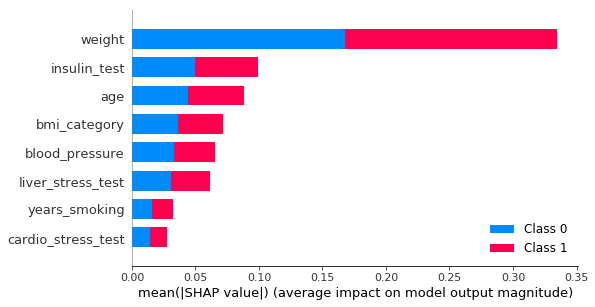

```python
explainer = shap.TreeExplainer(rf_best)
shap_values = explainer.shap_values(X_test_sm)
shap.summary_plot(shap_values, X_test_sm, plot_type="bar")
```

## Predict Test Dataset

```python
test_data = pd.read_csv("../Input/recruiting_zeta-disease_prediction-data_take-home-challenge - 2021-01-21_zeta-disease_prediction-data_take-home-challenge.csv")
```

```python
test_data_copy = test_data.copy(deep=True)
```

```python
test_data['bmi_category'] = test_data['bmi'].apply(lambda x: bmi_category(x))
test_data.drop(['bmi', 'zeta_disease'], axis = 1, inplace = True)
```

```python
Y_predict = pipeline_sm_rf.predict(test_data)
```

```python
Counter(Y_predict)
```

```
Counter({0: 8, 1: 12})
```

```python
test_data_copy['zeta_disease'] = Y_predict
```

```python
test_data_copy
```

|  | age | weight | bmi | blood_pressure | insulin_test | liver_stress_test | cardio_stress_test | years_smoking | zeta_disease |
| --- | --- | --- | --- | --- | --- | --- | --- | --- | --- |
| 0 | 24 | 151 | 39.5 | 69 | 72 | 1.3968 | 56 | 4 | 0 |
| 1 | 27 | 179 | 35.5 | 89 | 156 | 1.6608 | 43 | 6 | 1 |
| 2 | 34 | 147 | 26.9 | 76 | 74 | 1.6958 | 53 | 2 | 0 |
| 3 | 35 | 206 | 32.4 | 73 | 127 | 1.4608 | 61 | 6 | 1 |
| 4 | 60 | 193 | 29.8 | 62 | 192 | 1.7798 | 65 | 9 | 0 |
| 5 | 45 | 120 | 36.5 | 108 | 50 | 1.2978 | 54 | 12 | 0 |
| 6 | 20 | 139 | 38.2 | 61 | 77 | 1.5818 | 68 | 3 | 0 |
| 7 | 23 | 137 | 31.2 | 70 | 73 | 1.4168 | 59 | 7 | 0 |
| 8 | 36 | 195 | 30.5 | 59 | 141 | 1.4498 | 59 | 6 | 1 |
| 9 | 19 | 193 | 25.8 | 84 | 66 | 1.7938 | 50 | 3 | 0 |
| 10 | 47 | 216 | 34.7 | 70 | 170 | 1.7238 | 58 | 7 | 1 |
| 11 | 40 | 200 | 30.4 | 69 | 128 | 1.3118 | 60 | 3 | 1 |
| 12 | 21 | 154 | 46.5 | 88 | 121 | 1.2498 | 68 | 4 | 0 |
| 13 | 52 | 196 | 31.3 | 90 | 167 | 1.9238 | 66 | 10 | 1 |
| 14 | 30 | 181 | 37.4 | 93 | 157 | 2.0508 | 80 | 5 | 1 |
| 15 | 46 | 213 | 26.5 | 70 | 133 | 1.4788 | 55 | 12 | 1 |
| 16 | 29 | 173 | 50.7 | 91 | 221 | 1.4878 | 83 | 3 | 1 |
| 17 | 36 | 202 | 42.8 | 72 | 273 | 1.8748 | 72 | 13 | 1 |
| 18 | 27 | 197 | 29.1 | 72 | 362 | 1.4298 | 69 | 4 | 1 |
| 19 | 44 | 184 | 33.9 | 104 | 141 | 1.3268 | 60 | 2 | 1 |

```python
## Save predictions to Output folder

test_data_copy.to_csv('../Output/Zeta_Disease_Predictions.csv', index = False)
```